# Calibration of Weights

Thomas Lumley

5 February 2015

# Stratified, unstratified, post-stratified

- Sample stratified by region: $n_r$ is fixed, $\pi_i=n_r/N_r$ for $i$ in region $r$
- Unstratified sample: $n_r$ is random, $\pi_i\approx n_r/N_r$
- Post-stratified sample: $n_r$ is random, but we adjust $\pi_i$ to equal $n_r/N_r$, weight is $N_r/n_r$

After post-stratification,
$$\hat N_r = \sum_{i\in\textrm{region}}\frac{1}{\pi_i} = n_r\times\frac{N_r}{n_r}=N_r$$

Estimation is **exact** for $N_r$, improved for anything correlated with region.

# Example:

```r
data(api)
dclus1<-svydesign(id=~dnum, weights=~pw, data=apiclus1, fpc=~fpc)
svymean(~api00, dclus1)
```

```
##         mean     SE
## api00 644.17 23.542
```

```r
svytotal(~enroll, dclus1)
```

```
##          total     SE
## enroll 3404940 932235
```

# Example:

```r
pop.types <- data.frame(stype=c("E","H","M"), Freq=c(4421,755,1018))
psclus1<-postStratify(dclus1, ~stype, pop.types)
svymean(~api00, psclus1)
```

```
##         mean     SE
## api00 642.31 23.921
```

```r
svytotal(~enroll, psclus1)
```

```
##          total     SE
## enroll 3680893 406293
```

```r
svytotal(~stype, dclus1)
```

```
##          total      SE
## stypeE 4873.97 1333.32
## stypeH  473.86  158.70
## stypeM  846.17  167.55
```

```r
svytotal(~stype, psclus1)
```

```
##        total SE
## stypeE  4421  0
## stypeH   755  0
## stypeM  1018  0
```

# Too good to be true?

- Post-stratification gains precision by using extra information: need to know $N_r$
- Post-stratification is always beneficial **asymptotically**.
- Stratification is always beneficial **even in small samples.**
- Post-stratified estimates can be **less** accurate if the post-strata are too small or the correlation is too weak.

# Regression estimator of total

Suppose we want $T_Y$, population total of $Y$, and we know $T_X$, population total of $X$, for some auxiliary variable $X$.

Horvitz–Thompson estimator is
$$\hat T_y = \sum_{i=1}^N \frac{R_i}{\pi_i}Y_i$$

Or, we could fit a regression model to the sample: $E[Y]=\alpha+\beta X$ and use the known information about $X$.

# Regression estimator

$$\tilde T_y = \sum_{i=1}^N \frac{R_i}{\pi_i}(Y_i-\hat\alpha-\hat\beta X_i)+\sum_{i=1}^N(\hat\alpha+\hat\beta X_i)$$
First term is zero by construction (no assumptions needed)

Second term is
$$\sum_{i=1}^N(\hat\alpha+\hat\beta X_i) = N\hat\alpha+T_X\hat\beta$$
so we only need $T_X$, not individual $X$ values.

# Efficiency gain

Rewrite as
$$\tilde T_y = \sum_{i=1}^N \frac{R_i}{\pi_i}(Y_i-\alpha-\beta X_i)+\left(N\alpha+T_X\beta\right)+\left(N(\hat\alpha-\alpha)+T_X(\hat\beta-\beta)\right)$$

$\tilde T_Y$ is more precise than $\hat T_Y$, at least asymptotically.

# Bias correction

To the extent that $X$ explains the correlation between $Y$ and non-response, calibration will reduce non-response bias

- the **real** reason it’s used in most surveys
- harder to say anything precise about, so not covered so much in theory

# Calibration of weights

$\tilde Y$ is a fitted value from linear regression, so it must be a weighted sum of $Y_i$, with weights that depend only on $X$

For **any** variable $Y$, we can write
$$\sum_{i\in\textrm{sample}}\tilde w_i Y_i = \tilde T_Y$$

In particular
$$\sum_{i\in\textrm{sample}}\tilde w_i X_i = \tilde T_X$$
so the calibrated weights $\tilde w_i$ give exactly correct population totals for the calibration variable $X$, and improved totals for variables correlated with $X$.

# Example:

```r
pop.totals<-c(`(Intercept)`=6194, stypeH=755, stypeM=1018)
dclus1cal <- calibrate(dclus1, ~stype+api99, c(pop.totals, api99=3914069))
svymean(~api00, dclus1)
```

```
##         mean     SE
## api00 644.17 23.542
```

```r
svymean(~api00, dclus1cal)
```

```
##         mean     SE
## api00 665.31 3.4418
```

Roughly 98% variance reduction, matching correlation between `api00` and `api99`

# Format of population data

The `formula` argument specifies a regression design matrix, and the `population` argument is the population column totals of this matrix

If you fitted a regression model with predictors `~stype+api99` the columns would be

- `(Intercept)`: sum is population size
- `stypeH`: sum is number of high schools
- `stypeM`: sum is number of middle schools
- `api99`: sum is population sum of `api99`

A function

```r
calibrate_names <-function(formula, design){
  mf<-model.frame(formula, model.frame(design))
  mm<-model.matrix(formula,mf[1,,drop=FALSE])
  colnames(mm)
}
calibrate_names(~stype+api99, dclus1)
```

```
## [1] "(Intercept)" "stypeH"      "stypeM"      "api99"
```

```r
calibrate_names(~stype*api99, dclus1)
```

```
## [1] "(Intercept)"  "stypeH"       "stypeM"       "api99"
## [5] "stypeH:api99" "stypeM:api99"
```

# General calibration of weights

Calibrated weights can be negative:

- official statistics agencies often don’t like this
- some software doesn’t like this

If we define $\tilde w_i$ as the “closest” values to $w_i$ that satisfy
$$\sum_{i\in\textrm{sample}}\tilde w_i X_i = \tilde T_X$$
we can choose our distance function to make negative weights infinitely distant.

# Distance and calibration

Distances are from $r=(\tilde w/w)$ to 1

- linear regression calibration: $d(r) = (r-1)^2$
- generalised raking: $d(r) = r\log r -r$
- logit calibration:
  $$d(r)=(r-L)\log\frac{(r-L)}{1-L}+(U-r)\log\frac{(U-r)}{U-1}$$

Logit calibration always has bounds $(L,U$). Bounds can be added to linear or raking by setting $d(r)=\infty$ at the bounds.

Bounds may not be achievable: obviously $L=U$ would be impossible.

# Best distance function?

All distance functions are **asymptotically** equivalent: as $n\to\infty$, $r\to 1$

Difference is mostly a matter of standard practice in your country.

I like raking, because negative weights are inconvenient and it doesn’t need any additional parameters.

```r
dclus1rake <- calibrate(dclus1, ~stype+api99,
          c(pop.totals, api99=3914069), calfun="raking")
dclus1logit <- calibrate(dclus1, ~stype+api99,
          c(pop.totals, api99=3914069), calfun="logit",bounds=c(0.5,2))
```

```r
svymean(~api00, dclus1cal)
```

```
##         mean     SE
## api00 665.31 3.4418
```

```r
svymean(~api00, dclus1rake)
```

```
##         mean     SE
## api00 665.39 3.4378
```

```r
svymean(~api00, dclus1logit)
```

```
##         mean     SE
## api00 665.59 3.4483
```

# Traditional raking

Calibration with $d(r) = r\log r -r$ is called *raking* because it’s the same estimator as the traditional raking (iterative proportional fitting) algorithm:

Suppose we have two post-stratification variables $X$ and $Z$. Could post-stratify on `X*Z`, but

- we may not know the joint distribution
- the cells might be too small

Raking: post-stratify on $X$ then on $Z$, iterate until it stops changing.

- matches *marginal totals* for the `X*Z` table to the population
- works with margins of any dimension, eg rake on `X1*X2`, `X2*X3`, `X3*X1`
- simple algorithm, guaranteed to converge if no zeroes in table

# Raking or calibration

Now we have calibration, no real advantage to raking

- `calibrate()` can use the raking distance function
- `calibrate()` can accept list of margins as description of population

```r
## Input in the same format as rake() for classical raking
pop.table <- xtabs(~stype+sch.wide,apipop)
pop.table2 <- xtabs(~stype+comp.imp,apipop)
dclus1r<-rake(dclus1, list(~stype+sch.wide, ~stype+comp.imp),
               list(pop.table, pop.table2))
gclus1r<-calibrate(dclus1, formula=list(~stype+sch.wide, ~stype+comp.imp),
     population=list(pop.table, pop.table2),calfun="raking")
svymean(~api00+stype, dclus1r)
```

```
##             mean     SE
## api00  642.87442 22.249
## stypeE   0.71376  0.000
## stypeH   0.12189  0.000
## stypeM   0.16435  0.000
```

```r
svymean(~api00+stype, gclus1r)
```

```
##             mean     SE
## api00  642.86932 22.244
## stypeE   0.71376  0.000
## stypeH   0.12189  0.000
## stypeM   0.16435  0.000
```

# Unattainable bounds

If bounds are specified and not attainable, use wider bounds and **trim** the weights:

- set weights above bound to bound
- reallocate the weight that was removed over all other observations
- iterate if necessary

# A Danish example:

**What I did on my summer holidays**

Population data on 200,000 people:

- age, gender ethnicity
- income, household income, household type

Sample data on 3500 people, with non-response

- business travel
- holiday travel
- foreign visitors

```r
social<-read.csv("~/STATS_DENMARK/social_data/social_sample.csv")
population<-read.csv("~/STATS_DENMARK/social_data/social_population.csv")
names(social)
```

```
## [1] "Id"       "Guests"   "Adults"   "Children" "Leisure"  "Business"
## [7] "Cottage"
```

```r
dim(social)
```

```
## [1] 3476    7
```

```r
names(population)
```

```
##  [1] "Id"        "Age"       "Income"    "Gender"    "Ethnicity"
##  [6] "AgeClass"  "SocEcon"   "HhIncome"  "HhType"    "Education"
```

# Missing data

```r
summary(social)
```

```
##        Id             Guests           Adults          Children
##  Min.   :300000   Min.   : 0.000   Min.   : 1.000   Min.   : 0.000
##  1st Qu.:300869   1st Qu.: 1.000   1st Qu.: 2.000   1st Qu.: 0.000
##  Median :301738   Median : 1.000   Median : 2.000   Median : 0.000
##  Mean   :301738   Mean   : 1.465   Mean   : 2.132   Mean   : 0.549
##  3rd Qu.:302606   3rd Qu.: 1.000   3rd Qu.: 2.000   3rd Qu.: 1.000
##  Max.   :303475   Max.   :20.000   Max.   :10.000   Max.   :99.000
##                   NA's   :3319     NA's   :953      NA's   :955
##     Leisure          Business          Cottage
##  Min.   : 0.000   Min.   : 0.0000   Min.   : 0.000
##  1st Qu.: 0.000   1st Qu.: 0.0000   1st Qu.: 0.000
##  Median : 0.000   Median : 0.0000   Median : 0.000
##  Mean   : 0.287   Mean   : 0.2038   Mean   : 1.258
##  3rd Qu.: 0.000   3rd Qu.: 0.0000   3rd Qu.: 1.000
##  Max.   :11.000   Max.   :50.0000   Max.   :50.000
##  NA's   :964      NA's   :964       NA's   :962
```

# Merge to add population data

```r
social <- merge(social, population, by="Id",keep=FALSE)
dim(social)
```

```
## [1] 3476   16
```

```r
names(social)
```

```
##  [1] "Id"        "Guests"    "Adults"    "Children"  "Leisure"
##  [6] "Business"  "Cottage"   "Age"       "Income"    "Gender"
## [11] "Ethnicity" "AgeClass"  "SocEcon"   "HhIncome"  "HhType"
## [16] "Education"
```

# Two-phase sampling

```r
social$popsize<-nrow(population)
social$nonmissing <- !with(social,
                       is.na(Leisure) | is.na(Business) | is.na(Cottage))
soc_gross<-svydesign(id=~1,data=social,fpc=~popsize)
soc_des<-twophase(id=list(~1,~1), strata=list(NULL,NULL),
                  fpc=list(~popsize, NULL),
                  subset=~nonmissing, data=social)
```

```r
c(Income=mean(population$Income), Male=mean(population$Gender==1))
```

```
##      Income        Male
## 242.5049834   0.4911439
```

```r
svymean(~Income+factor(Gender),design=soc_gross)
```

```
##                     mean     SE
## Income          241.1574 3.6176
## factor(Gender)1   0.4767 0.0084
## factor(Gender)2   0.5233 0.0084
```

```r
svymean(~Income+factor(Gender),design=soc_des)
```

```
##                      mean     SE
## Income          258.23487 4.5729
## factor(Gender)1   0.46855 0.0099
## factor(Gender)2   0.53145 0.0099
```

# Calibrate to phase 1

Calibration of phase 2 to phase 1 for a discrete variable is basically “Response Homogeneity Groups”: no auxiliary population data needed.

```r
soc_rhg <- calibrate(soc_des, phase=2,
                     formula=~Ethnicity+factor(AgeClass)+factor(HhType),
                     calfun="raking")
```

# After calibration

```r
svymean(~Income+factor(Gender),design=soc_des)
```

```
##                      mean     SE
## Income          258.23487 4.5729
## factor(Gender)1   0.46855 0.0099
## factor(Gender)2   0.53145 0.0099
```

```r
svymean(~Income+factor(Gender),design=soc_rhg)
```

```
##                     mean     SE
## Income          245.0286 4.0268
## factor(Gender)1   0.4678 0.0101
## factor(Gender)2   0.5322 0.0101
```

```r
svymean(~factor(HhType),soc_gross)
```

```
##                     mean     SE
## factor(HhType)1 0.257768 0.0074
## factor(HhType)2 0.051784 0.0037
## factor(HhType)3 0.262658 0.0074
## factor(HhType)4 0.296318 0.0077
## factor(HhType)5 0.069045 0.0043
## factor(HhType)6 0.062428 0.0041
```

```r
svymean(~factor(HhType),soc_des)
```

```
##                     mean     SE
## factor(HhType)1 0.200239 0.0079
## factor(HhType)2 0.048965 0.0043
## factor(HhType)3 0.295382 0.0090
## factor(HhType)4 0.331608 0.0093
## factor(HhType)5 0.062102 0.0048
## factor(HhType)6 0.061704 0.0048
```

```r
svymean(~factor(HhType),soc_gross)
```

```
##                     mean     SE
## factor(HhType)1 0.257768 0.0074
## factor(HhType)2 0.051784 0.0037
## factor(HhType)3 0.262658 0.0074
## factor(HhType)4 0.296318 0.0077
## factor(HhType)5 0.069045 0.0043
## factor(HhType)6 0.062428 0.0041
```

```r
svymean(~factor(HhType),soc_rhg)
```

```
##                     mean     SE
## factor(HhType)1 0.257768 0.0081
## factor(HhType)2 0.051784 0.0039
## factor(HhType)3 0.262658 0.0072
## factor(HhType)4 0.296318 0.0076
## factor(HhType)5 0.069045 0.0045
## factor(HhType)6 0.062428 0.0041
```

```r
hist_net<-svysmooth(~Income, design=soc_des)
hist_rhg<-svysmooth(~Income, design=soc_rhg)
```

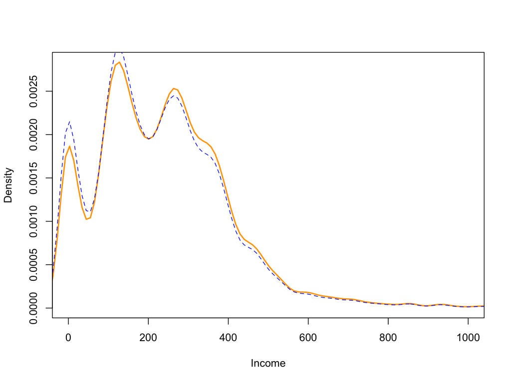

```r
plot(hist_net,col="orange",lwd=2, xlim=c(0,1000))
lines(hist_rhg,col="blue",lty=2)
```

# Does it matter?

```r
svymean(~Leisure+Business+Cottage, design=soc_des)
```

```
##             mean     SE
## Leisure  0.28702 0.0117
## Business 0.20382 0.0288
## Cottage  1.25876 0.0644
```

```r
svymean(~Leisure+Business+Cottage, design=soc_rhg)
```

```
##             mean     SE
## Leisure  0.28165 0.0117
## Business 0.18876 0.0253
## Cottage  1.29139 0.0680
```

```r
svymean(~I(Leisure>0)+I(Business>0)+I(Cottage>0), design=soc_des)
```

```
##                          mean     SE
## I(Leisure > 0)FALSE  0.759156 0.0085
## I(Leisure > 0)TRUE   0.240844 0.0085
## I(Business > 0)FALSE 0.924363 0.0052
## I(Business > 0)TRUE  0.075637 0.0052
## I(Cottage > 0)FALSE  0.613854 0.0097
## I(Cottage > 0)TRUE   0.386146 0.0097
```

```r
svymean(~I(Leisure>0)+I(Business>0)+I(Cottage>0), design=soc_rhg)
```

```
##                          mean     SE
## I(Leisure > 0)FALSE  0.764122 0.0085
## I(Leisure > 0)TRUE   0.235878 0.0085
## I(Business > 0)FALSE 0.926488 0.0052
## I(Business > 0)TRUE  0.073512 0.0052
## I(Cottage > 0)FALSE  0.611142 0.0098
## I(Cottage > 0)TRUE   0.388858 0.0098
```

# Calibrate to population

Or, could treat net sample as the sample and calibrate to the population

Need population totals for column sums of design matrix, or list of marginal tables

```r
pop.frame<-model.frame(~Ethnicity+factor(AgeClass)+factor(HhType),
                       population)
pop.sums<-colSums(model.matrix(~Ethnicity+factor(AgeClass)+factor(HhType),
                               pop.frame))
pop.sums
```

```
##       (Intercept)         Ethnicity factor(AgeClass)2 factor(AgeClass)3
##            203476            223427             30000             35996
## factor(AgeClass)4 factor(AgeClass)5 factor(AgeClass)6   factor(HhType)2
##             33978             32182             40140             11890
##   factor(HhType)3   factor(HhType)4   factor(HhType)5   factor(HhType)6
##             48573             56718             15223             13564
```

```r
soc_net<-svydesign(id=~1,data=subset(social,nonmissing),fpc=~popsize)

soc_cal <- calibrate(soc_net, population=pop.sums,
                     formula=~Ethnicity+factor(AgeClass)+factor(HhType),
                     calfun="raking")
```

# After calibration

```r
svymean(~Income+factor(Gender),design=soc_net)
```

```
##                      mean     SE
## Income          258.23487 4.5729
## factor(Gender)1   0.46855 0.0099
## factor(Gender)2   0.53145 0.0099
```

```r
svymean(~Income+factor(Gender),design=soc_cal)
```

```
##                      mean     SE
## Income          244.80282 3.5165
## factor(Gender)1   0.46701 0.0103
## factor(Gender)2   0.53299 0.0103
```

```r
svymean(~factor(HhType),soc_net)
```

```
##                     mean     SE
## factor(HhType)1 0.200239 0.0079
## factor(HhType)2 0.048965 0.0043
## factor(HhType)3 0.295382 0.0090
## factor(HhType)4 0.331608 0.0093
## factor(HhType)5 0.062102 0.0048
## factor(HhType)6 0.061704 0.0048
```

```r
svymean(~factor(HhType),soc_cal)
```

```
##                     mean SE
## factor(HhType)1 0.282628  0
## factor(HhType)2 0.058434  0
## factor(HhType)3 0.238716  0
## factor(HhType)4 0.278745  0
## factor(HhType)5 0.074815  0
## factor(HhType)6 0.066661  0
```

```r
svymean(~factor(HhType),soc_net)
```

```
##                     mean     SE
## factor(HhType)1 0.200239 0.0079
## factor(HhType)2 0.048965 0.0043
## factor(HhType)3 0.295382 0.0090
## factor(HhType)4 0.331608 0.0093
## factor(HhType)5 0.062102 0.0048
## factor(HhType)6 0.061704 0.0048
```

```r
svymean(~factor(HhType),soc_cal)
```

```
##                     mean SE
## factor(HhType)1 0.282628  0
## factor(HhType)2 0.058434  0
## factor(HhType)3 0.238716  0
## factor(HhType)4 0.278745  0
## factor(HhType)5 0.074815  0
## factor(HhType)6 0.066661  0
```

```r
hist_net<-svysmooth(~Income, design=soc_net)
hist_cal<-svysmooth(~Income, design=soc_cal)
```

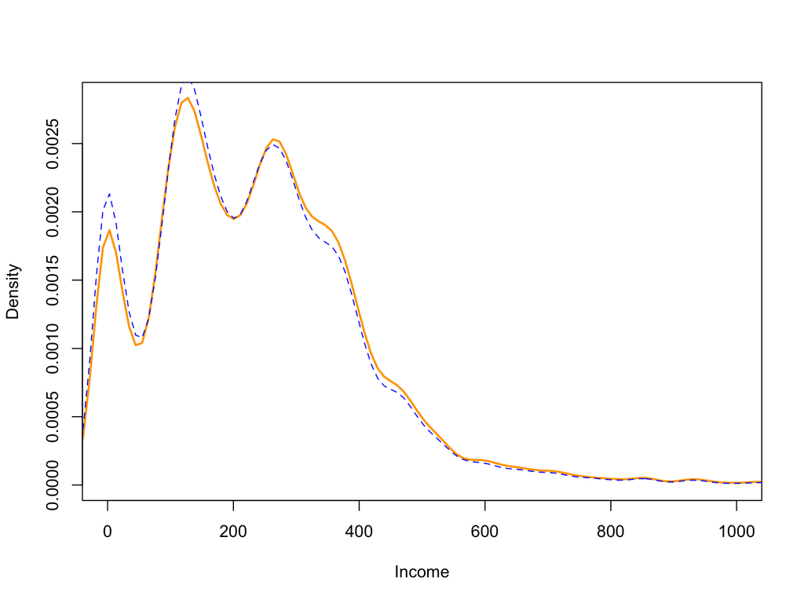

```r
plot(hist_net,col="orange",lwd=2, xlim=c(0,1000))
lines(hist_cal,col="blue",lty=2)
```

# Does it matter?

```r
svymean(~Leisure+Business+Cottage, design=soc_net)
```

```
##             mean     SE
## Leisure  0.28702 0.0117
## Business 0.20382 0.0288
## Cottage  1.25876 0.0644
```

```r
svymean(~Leisure+Business+Cottage, design=soc_cal)
```

```
##             mean     SE
## Leisure  0.28135 0.0120
## Business 0.18876 0.0242
## Cottage  1.29316 0.0665
```

```r
svymean(~I(Leisure>0)+I(Business>0)+I(Cottage>0), design=soc_net)
```

```
##                          mean     SE
## I(Leisure > 0)FALSE  0.759156 0.0085
## I(Leisure > 0)TRUE   0.240844 0.0085
## I(Business > 0)FALSE 0.924363 0.0052
## I(Business > 0)TRUE  0.075637 0.0052
## I(Cottage > 0)FALSE  0.613854 0.0097
## I(Cottage > 0)TRUE   0.386146 0.0097
```

```r
svymean(~I(Leisure>0)+I(Business>0)+I(Cottage>0), design=soc_cal)
```

```
##                         mean     SE
## I(Leisure > 0)FALSE  0.76529 0.0086
## I(Leisure > 0)TRUE   0.23471 0.0086
## I(Business > 0)FALSE 0.92435 0.0054
## I(Business > 0)TRUE  0.07565 0.0054
## I(Cottage > 0)FALSE  0.60698 0.0098
## I(Cottage > 0)TRUE   0.39302 0.0098
```

# Beyond totals

Precision gain for $T_Y$ from calibrating on $X$ depends on correlation between $X$ and $Y$.

How does this translate to other statistics such as regression coefficients?

- Any statistic is approximately the total of its influence functions
- To calibrate for estimating $\hat\beta$, use an auxiliary variable correlated with the influence functions
- Variables in the model will **not** be strongly correlated with the influence function.

# Example

In linear regression of $Y$ on $X$, influence function for $\beta$ is proportional to
$$(X-\bar X)(Y-\hat Y)$$
which is uncorrelated with $X$ and $Y$.

# Choice of calibration variable

- Optimal choice is $E[U(\beta)\mid \textrm{population/Phase I data}]$
- This isn’t feasible, it is too complicated and depends on unknown things.
- A good **practical** choice is influence functions for a model with imputed Phase II information.

[Breslow et al, 2009 Am J Epi, Stat Biosci]

- Fit imputation model to predict $X$ from Phase I $Y$ and $Z$
- Fit analysis model to full data using imputed $X$ even when real $X$ is available
- Extract influence functions, and use for calibration
- Fit analysis model to calibrated Phase II sample

# Example: Regression in California schools

Assume we know the predictor variables and `api99` on the population, measure `api00` in the sample.

We could impute `api00` by `api99`, since they are highly correlated

# What are the correlations like?

```r
pop_99 <- lm(api99~ell+meals,data=apipop)
pop_00 <- lm(api00~ell+meals,data=apipop)
inffun99 <- dfbeta(pop_99)
inffun00 <- dfbeta(pop_00)
```

# Influence fn vs outcome

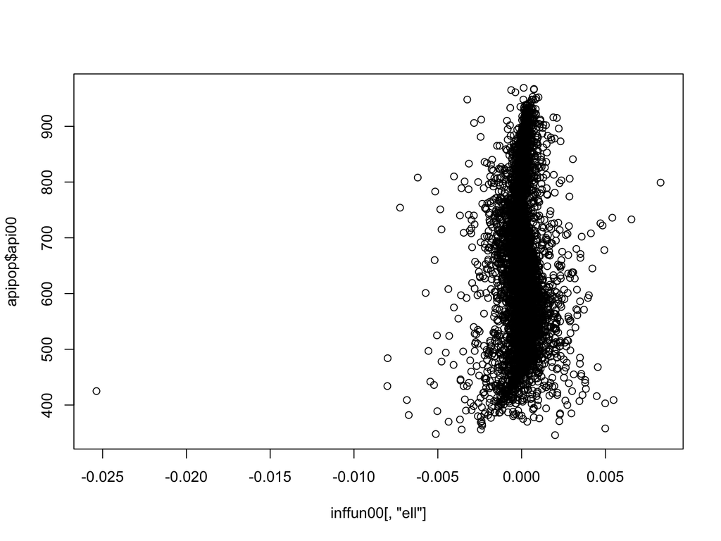

```r
plot(inffun00[,"ell"],apipop$api00)
```

# Influence fn vs predictor

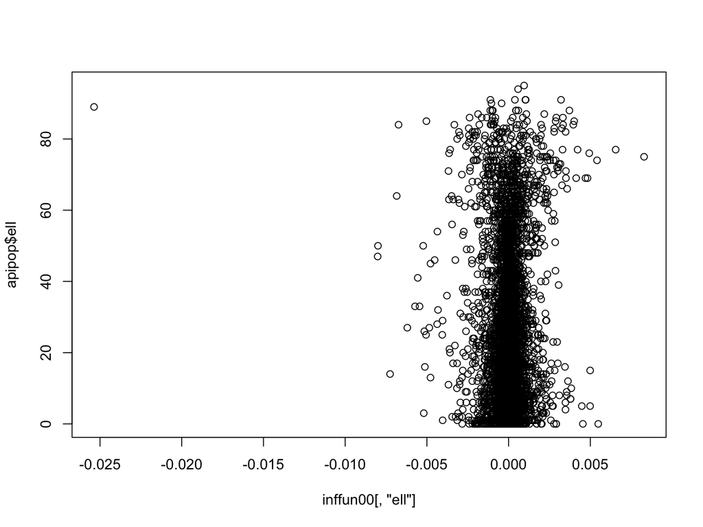

```r
plot(inffun00[,"ell"],apipop$ell)
```

# Influence fn vs influence fn

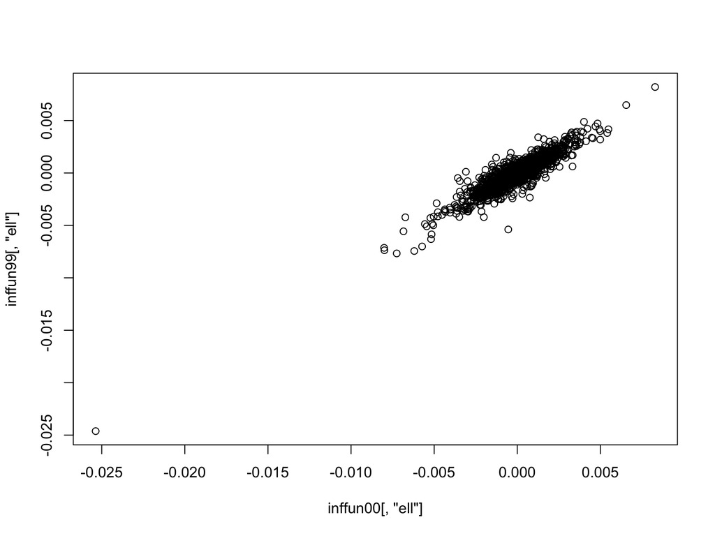

```r
plot(inffun00[,"ell"],inffun99[,"ell"])
```

# Calibration

```r
colSums(apipop[,c("api99","ell","meals")])
```

```
##   api99     ell   meals
## 3914069  141685  297533
```

```r
insample <- match(apiclus1$snum,apipop$snum)
dclus1<-update(dclus1, inf1=inffun99[insample,1],
               inf2=inffun99[insample,2],
               inf3=inffun99[insample,3])
cal_variables = calibrate(dclus1, ~api99+ell+meals,
                          population=c(6194, 3914069, 141685, 297533 ))
cal_inffun = calibrate(dclus1, ~inf1+inf2+inf3,
                          population=c(6194,0,0,0))
```

# Calibration on variables

```r
coef(summary(svyglm(api00~ell+meals, dclus1)))
```

```
##                Estimate Std. Error    t value     Pr(>|t|)
## (Intercept) 817.1822885 18.6708927  43.767714 1.316566e-14
## ell          -0.5087967  0.3259227  -1.561096 1.444743e-01
## meals        -3.1455892  0.3018025 -10.422673 2.285616e-07
```

```r
coef(summary(svyglm(api00~ell+meals, cal_variables)))
```

```
##                Estimate Std. Error   t value     Pr(>|t|)
## (Intercept) 829.3516492 11.7783565  70.41319 4.474062e-17
## ell          -0.5235294  0.5100787  -1.02637 3.249626e-01
## meals        -3.1662593  0.3078772 -10.28416 2.643624e-07
```

# Calibration on influence functions

```r
coef(summary(svyglm(api00~ell+meals, dclus1)))
```

```
##                Estimate Std. Error    t value     Pr(>|t|)
## (Intercept) 817.1822885 18.6708927  43.767714 1.316566e-14
## ell          -0.5087967  0.3259227  -1.561096 1.444743e-01
## meals        -3.1455892  0.3018025 -10.422673 2.285616e-07
```

```r
coef(summary(svyglm(api00~ell+meals, cal_inffun)))
```

```
##                Estimate Std. Error    t value     Pr(>|t|)
## (Intercept) 825.1594280  5.1851558 159.138790 2.546482e-21
## ell          -0.5648151  0.1753161  -3.221695 7.331390e-03
## meals        -3.0550267  0.1249211 -24.455644 1.317584e-11
```

# Calibration

- Calibration, raking, post-stratification provide a way to add population or full-cohort information to a survey
- No additional assumptions are needed, and precision is asymptotically always better
- When estimating a regression parameter, think of it as sum of influence functions
  - a good calibration variable will be correlated with the influence functions
  - influence functions from a related model are one good choice.